# Clustering High Collision Areas in Toronto

Jason Kim

# Extract, Transform, and Loading the Dataset

The differences between this dataset and the original collisions.csv dataset are that the following ETL processes were applied to it:

- only car-on-pedestrian and car-on-cyclist collisions were kept; car-on-car, car-on-property collisions were excluded
- spatial joined in QGIS using the Toronto Neighbourhoods shapefile, which added a Neighourhood ID and Neighbourhood name field to each observation (if a collision took place within the boundaries of a neighbourhood, it was given the corresponding Neighbourhood label)
- spatial joined in QGIS using the Toronto Centrelines shapefile, which added a unique street ID (LFN_ID) and total length in kilometres of the primary road the collision took place on as new fields to the dataset
- street name columns were merged into a single column called street1
- engineered several binary features which check whether an area has above the city’s average for that measure. E.g. businessess_check checks whether the area has more than the average number of businesses or not.

# Pre-processing the Data

Once the different datasets from different sources are ready, they need to be joined.

```r
dim(pedestrian.df)
```

[output not shown]

# Data Cleaning

```r
dim(pedestrian.df)
```

[output not shown]

# Exploring the Data

Prior to modelling, we should obtain an untuitive understanding of the problem of collisions in Toronto.

```r
toronto_map <- ggmap(get_googlemap(center = c(-79.4, 43.7), zoom = 11, scale = 1, maptype = "roadmap"))
```

[figure not shown]

# Clustering Collision Densities by Location

Prior to classification, we need to group the collision densities (where collisions occur within a set radius). We use three methods of grouping collision densities:

1. Kernel Density Estimation (KDE)
2. K-means Clustering
3. Density Based Spatial Clustering and Application with Noise (DBSCAN)

By using unsupervised learning to group these collision densities we can create a map of collision hotspots and then model the data to examine shared chareristics and classify unseen data.

## Kernel Density Estimation (KDE)

```r
sort(table(sapply(conlines, `[[`, "level")))
```

```
70.4730622133642 29.7863407789229 15.5370852592917 11.4999442837367
               1                2                5                7
```

## *K-means Clustering*

Rather than clustering collisions by kernel densities, we can also cluster using k-means clustering which is an unsupervised learning algorithm. Below we find the optimal value for **k**, which is the number of clusters our model will attempt to fit the points. Effectively, this will cluster collisions into discrete concentrations based on location not unlike KDE, but using the shortest Eucledean distance to the centroid rather than kernel density. Thus, I expect the two models to look somewhat similar to each other, but k-means will have potentially many elliptically-shaped clusters rather than the organic, blob-like shape KDE creates.

```r
toronto_map + geom_point(aes(x = longitude, y = latitude, color = cluster, alpha = 0.4), data = pedestrian.kmeans)
```

[output not shown]

## Density-based Spatial Clustering and Application with Noise (DBSCAN)

Similar in logic to both KNN and KDE, this clustering algorithm is said to have better performance for clusters of linear shape. Since my data is based on collisions on streets which have a linear shape and a lot of outliers (aka noise), it is expected for DBSCAN to perform well in this case vs. k-means which is effective at clustering points in an eliptical shape and with little noise. Another benefit of DBSCAN is that it requires no **k** to be set ahead of time. Much like KNN, it requires the minimum amount of neighbours to be set, as well as **epsilon**, which is the radius of the neighbourhood. In DBSCAN, it is possible for a point to not belong to any cluster which is beneficial in this case since we want to prioritize areas with high concentrations of collisions.

```
   cluster  size ave.sil.width
0        0   544         -0.82
1        1   261          0.58
2        2   101          0.50
3        3   215          0.41
4        4    94          0.25
5        5    29          0.51
6        6    26          0.50
7        7    17          0.62
8        8 12594         -0.30
9        9   351          0.25
10      10   313          0.50
11      11   433          0.30
12      12    18          0.90
13      13    33          0.74
14      14    17          0.96
15      15    34          0.97
16      16   397          0.23
17      17    60          0.63
18      18    20          0.86
19      19    20          0.87
20      20   145          0.69
```

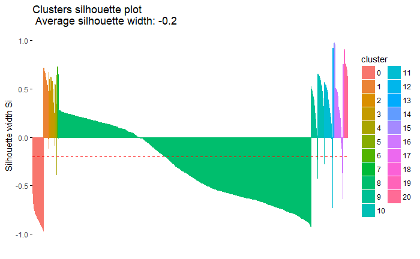

```r
# plot results
fviz_silhouette(silhouette_dbscan, print.summary = T)
```

# Classification

We have so far used 3 clustering methods to group collisions based on their geo-spatial attributes. These clusters were then added as new features to the dataset so we can see whether they are good predictors. For classification purposes, we can’t use KDE, but we can use both k-means and DBSCAN in order to see if there are shared characteristics between collisions and come up with a way to profile high collision zones.

*Creating a Training and Test Set* I created a training and test set in case I want to use a supervised machine learning algorithm for classifcation.

```r
prop.table(table(test_pedestrian$kmeans_cluster))
```

```
        1         2         3         4
0.1394757 0.2257572 0.4021379 0.2326292
```

## *K-means Clustering Classification Model*

```
  cluster size ave.sil.width
1       1 1710          0.17
2       2 2441          0.20
3       3 1069          0.26
4       4 2745          0.21
5       5 2648          0.12
6       6 1180          0.42
```

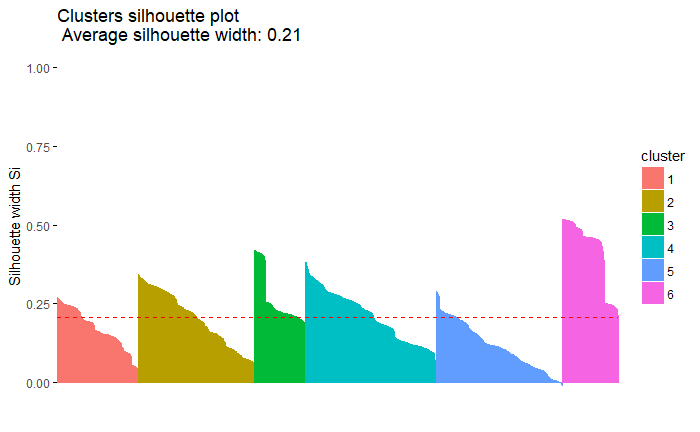

```r
fviz_silhouette(silhouette_k6, print.summary = T)
```

## *DBSCAN Classification*

[figure not shown]

## *Using Random Forest to Profile Clusters*

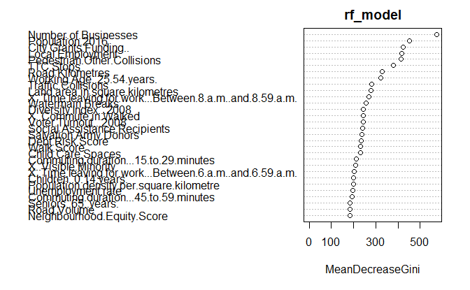